# Data Science Capstone Milestone Report

Erich Wolf

Sunday, July 26, 2015

## Executive Summary

This report is a summary of the work I have done so far on the Coursera Data Science Specialization Capstone. It will review how I have loaded and explored the text data. My ideas on how to proceed are also included.

## 1. Load Data

The data used for this analysis are three datasets from SwitfKey provided by the course and can be found at [here](https://d396qusza40orc.cloudfront.net/dsscapstone/dataset/Coursera-SwiftKey.zip). The three files are downloaded into my working directory and then read into r with the following code which also loads the required libraries:

```r
blogfile <- file("en_US.blogs.txt", open = "rb")
blogs <- readLines(blogfile, encoding = "UTF-8", warn=FALSE)
newsfile <- file("en_US.news.txt", open = "rb")
news <- readLines(newsfile, encoding = "UTF-8", warn=FALSE)
twitterfile <- file("en_US.twitter.txt", open = "rb")
twitter <- readLines(twitterfile, encoding = "UTF-8", warn=FALSE)
library(NLP)
library(tm)
library(RColorBrewer)
library(wordcloud)
```

## 2. Explore Data

I have counted the lines, total number of words, and unique number of words in each data set.

```r
lctwitter <- as.numeric(length(twitter))
lcnews <- as.numeric(length(news))
lcblogs <- as.numeric(length(blogs))
wordstwitter <- unlist(strsplit(twitter,"\\s+"))
wctwitter <- as.numeric(length(wordstwitter))
uwordstwitter <- unique(wordstwitter)
uwctwitter <- as.numeric(length(uwordstwitter))
wordsnews <- unlist(strsplit(news,"\\s+"))
wcnews <- as.numeric(length(wordsnews))
uwordsnews <- unique(wordsnews)
uwcnews <- as.numeric(length(uwordsnews))
wordsblogs <- unlist(strsplit(blogs,"\\s+"))
wcblogs <- as.numeric(length(wordsblogs))
uwordsblogs <- unique(wordsblogs)
uwcblogs <- as.numeric(length(uwordsblogs))

DataSet <- c("# of Lines", "# of Words", "# of Unique Words")
TwitterData <- c(lctwitter, wctwitter, uwctwitter)
NewsData <- c(lcnews, wcnews, uwcnews)
BlogsData <- c(lcblogs, wcblogs, uwcblogs)

datatable <- as.data.frame(rbind(TwitterData,NewsData,BlogsData))
colnames(datatable) <-DataSet
datatable
```

```
##             # of Lines # of Words # of Unique Words
## TwitterData    2360148   30373543           1290170
## NewsData       1010242   34372530            876772
## BlogsData       899288   37334131           1103548
```

I took a sample of 10,000 entries from each data set and combined them to create a single data set and reduce the processing time required for computations.

```r
sampletwitter <- sample(twitter,10000)
sampleblogs <- sample(blogs,10000)
samplenews <- sample(news,10000)
samplecombined <- c(sampletwitter,sampleblogs,samplenews)
```

I cleaned the smaller sample to eliminate numbers, URLs, excess whitespace, and profanity

```r
sampleCorpus <- VCorpus(VectorSource(samplecombined))
cleanCorpus <- tm_map(sampleCorpus,
                      content_transformer(function(x) iconv(x, to="UTF-8", sub="byte")),
                      mc.cores=1)
cleanCorpus <- tm_map(cleanCorpus, content_transformer(tolower), lazy = TRUE)
cleanCorpus <- tm_map(cleanCorpus, content_transformer(removePunctuation))
cleanCorpus <- tm_map(cleanCorpus, content_transformer(removeNumbers))
removeURL <- function(x) gsub("http[[:alnum:]]*", "", x)
cleanCorpus <- tm_map(cleanCorpus, content_transformer(removeURL))
cleanCorpus <- tm_map(cleanCorpus, stripWhitespace)
cleanCorpus <- tm_map(cleanCorpus, removeWords, stopwords("english"))
profanity <- readLines("en_profanity.txt")
cleanCorpus <- tm_map(cleanCorpus, removeWords, profanity)
```

A histogram of the top 10 most frequently used words in the English language is provided

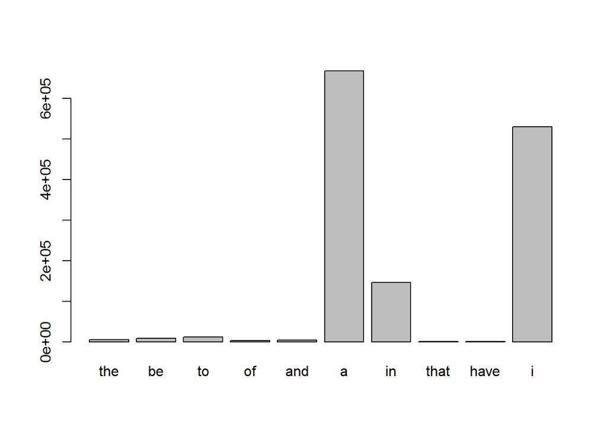

```r
the <- as.numeric(sum(sapply(gregexpr("[^*]the[^*]",cleanCorpus),length)))
be <- as.numeric(sum(sapply(gregexpr("[^*]be[^*]",cleanCorpus),length)))
to <- as.numeric(sum(sapply(gregexpr("[^*]to[^*]",cleanCorpus),length)))
of <- as.numeric(sum(sapply(gregexpr("[^*]of[^*]",cleanCorpus),length)))
and <- as.numeric(sum(sapply(gregexpr("[^*]and[^*]",cleanCorpus),length)))
a <- as.numeric(sum(sapply(gregexpr("[^*]a[^*]",cleanCorpus),length)))
ins <- as.numeric(sum(sapply(gregexpr("[^*]in[^*]",cleanCorpus),length)))
that <- as.numeric(sum(sapply(gregexpr("[^*]that[^*]",cleanCorpus),length)))
have <- as.numeric(sum(sapply(gregexpr("[^*]have[^*]",cleanCorpus),length)))
i <- as.numeric(sum(sapply(gregexpr("[^*]i[^*]",cleanCorpus),length)))
labels <- c("the","be","to","of","and","a","in","that","have","i")
y <- c(the,be,to,of,and,a,ins,that,have,i)
barplot(height=y,names.arg=labels)
```

A WordCloud of the cleaned data is also provided, please not that the WordCloud and Corpus functions exclude different stopwords so the two plots may nit match up exactly.

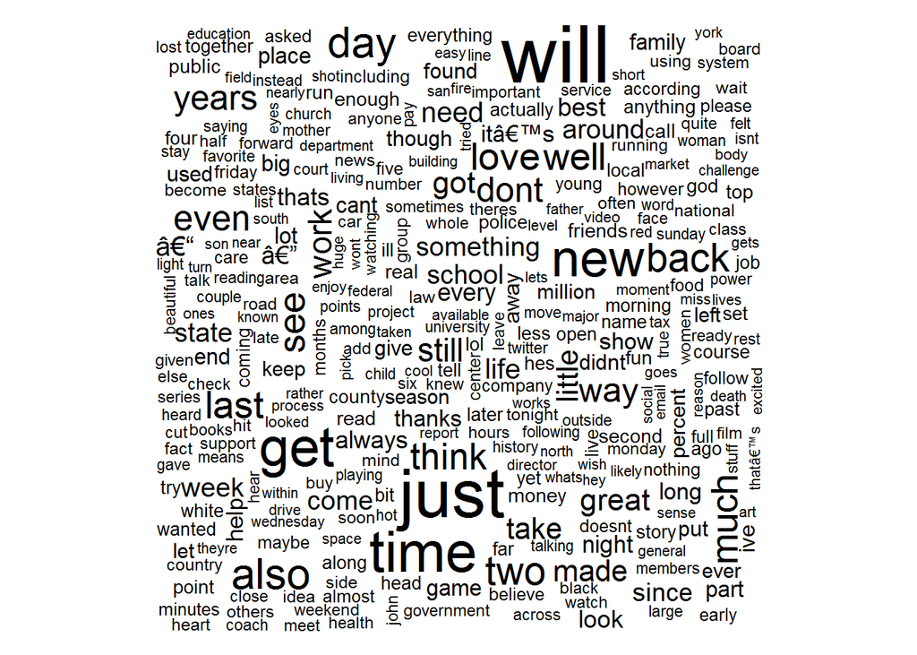

```r
suppressWarnings(wordcloud(cleanCorpus, max.words = 500))
```

## 3. Path Forward

My path forward will include developing n-grams of the data to identify common words and combinations of words, using these n-grams to create a model that will predict the next word following an n-gram, and determining how to make predictions for inputs that are not covered by the developed n-grams.